# Describing Data Graphically with R

Mason Garrison

February 10, 2026

# Hans Rosling

[video not shown]

# Summarize

- Transform a pile of numbers into a summary
- Descriptive Statistics
  - Distribution of a variable is a table/graph showing the categories/values of outcomes and their frequency/percentage of occurrence
  - Exploratory Data Analysis (John W. Tukey 1977)

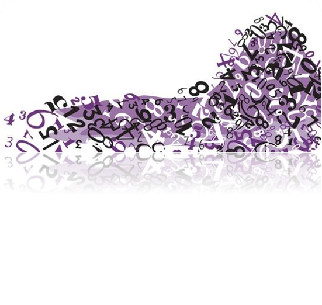

# Exploratory Data Analysis

- John W. Tukey (1977)
  - EDA
  - Graphical Data Analysis
  - Numbers as summaries
  - Emphasized Robust Statistics

[figure not shown]

# Descriptive Statistics

- Examples
  - Tables
  - Graphs
  - Summary Statistics

#Examples - Tables - Woodbridge (1845)

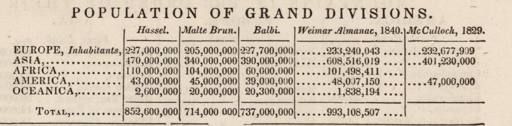

# Examples

- Graphs
  - Minard (1869)

# Examples

- Summary Statistics
  - Measures of Central Tendency
  - Measures of Spread

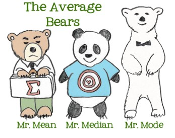

# Categorical Variable Displays (Nominal, Ordinal)

- Frequency Distribution Graphs
  - Bar Chart
  - Pie Chart
- Quantitative Variables
  - Histograms
  - Stem plots
- Time Plots

# Frequency distribution graph

- Bart Chart
  - Graphs of variables with categories of outcomes on the x axis; and the frequency or percent of each category on the Y axis.

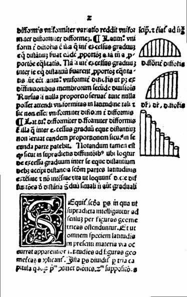

Nicole Oresme (Bishop of Lisieus) circa 1350

# Bar Graph/Chart

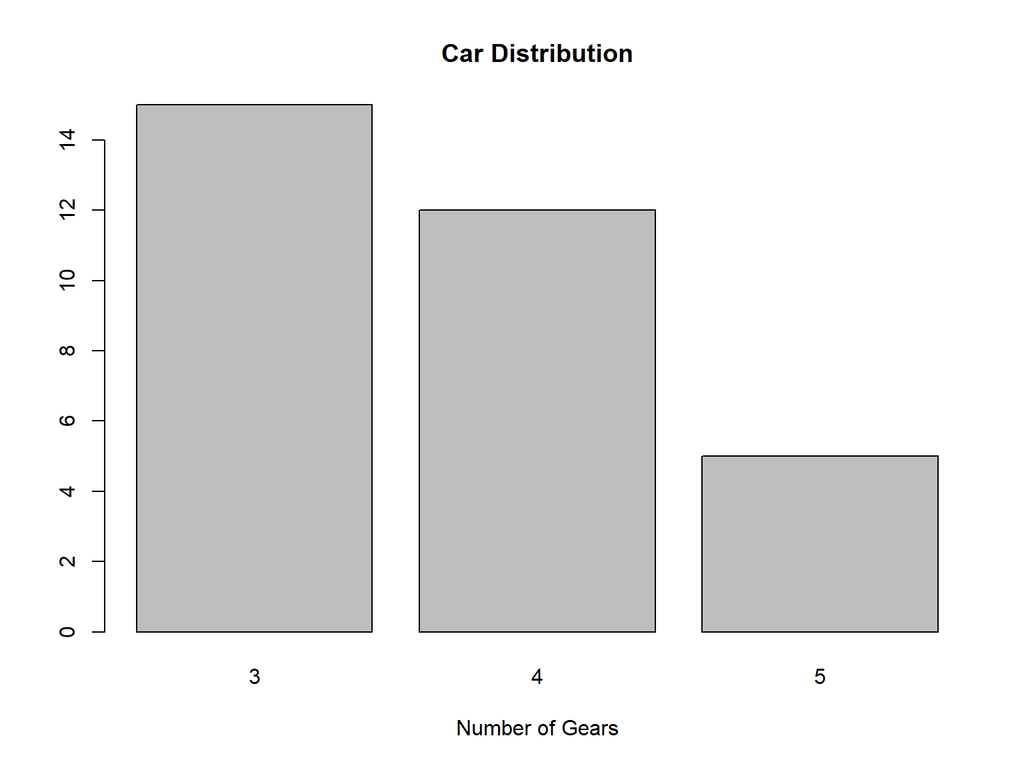

```r
# Bar chart
library(car)
counts <- table(mtcars$gear)
barplot(counts, main="Car Distribution",
    xlab="Number of Gears")
```

# Stacked Bar Chart

```r
df <- data.frame(
  group = c("Male", "Female", "Child"),
  value = c(25, 25, 50)
  )
head(df)
```

```
##    group value
## 1   Male    25
## 2 Female    25
## 3  Child    50
```

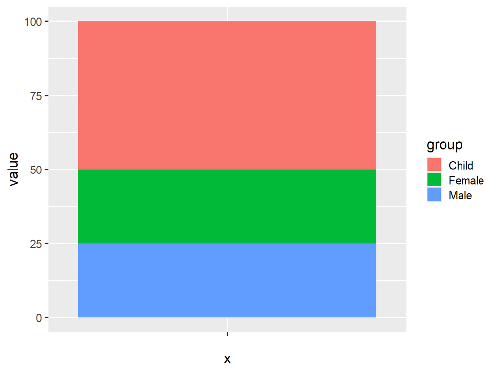

```r
library(ggplot2)
# Barplot
bp<- ggplot(df, aes(x="", y=value, fill=group))+
geom_bar(width = 1, stat = "identity")
bp
```

# Pie Chart

- Graphs of variables with categories of outcomes as frequency or percent of each category in the pie.

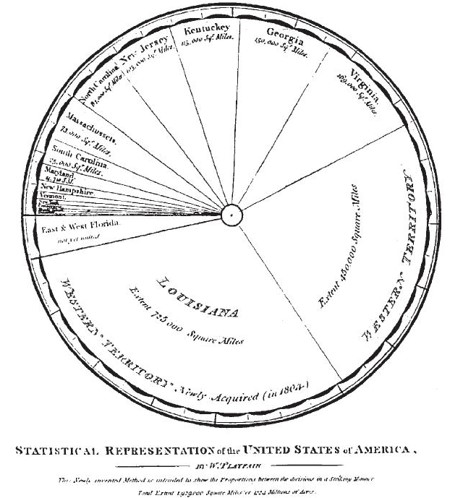

A pie chart showing each state in the United States, part of Playfair’s translation of A Statistical Account of the United States of America by D. F. Donnant.

# R Examples

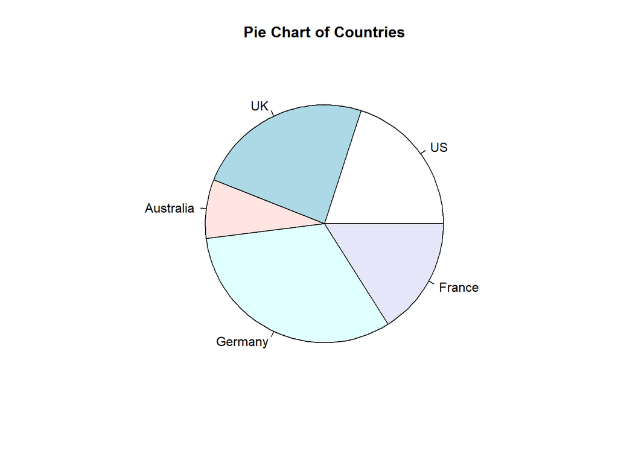

```r
# Pie chart
# Example 1
slices <- c(10, 12,4, 16, 8)
lbls <- c("US", "UK", "Australia", "Germany", "France")
pie(slices, labels = lbls, main="Pie Chart of Countries")
```

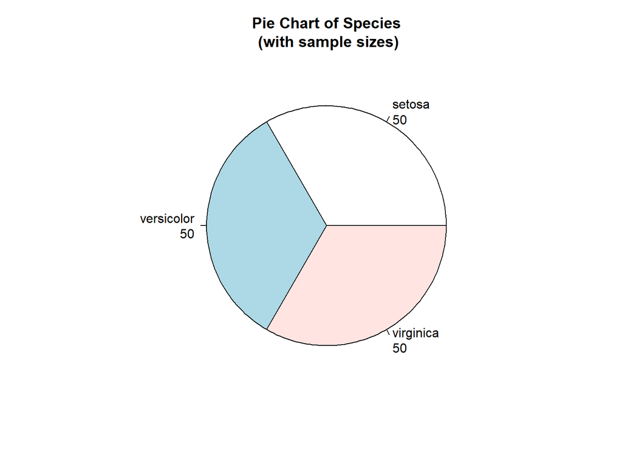

```r
# Example 2
mytable <- table(iris$Species)
lbls <- paste(names(mytable), "\n", mytable, sep="")
pie(mytable, labels = lbls,
        main="Pie Chart of Species\n (with sample sizes)")
```

# Convert Bar Chart into Pie Chart

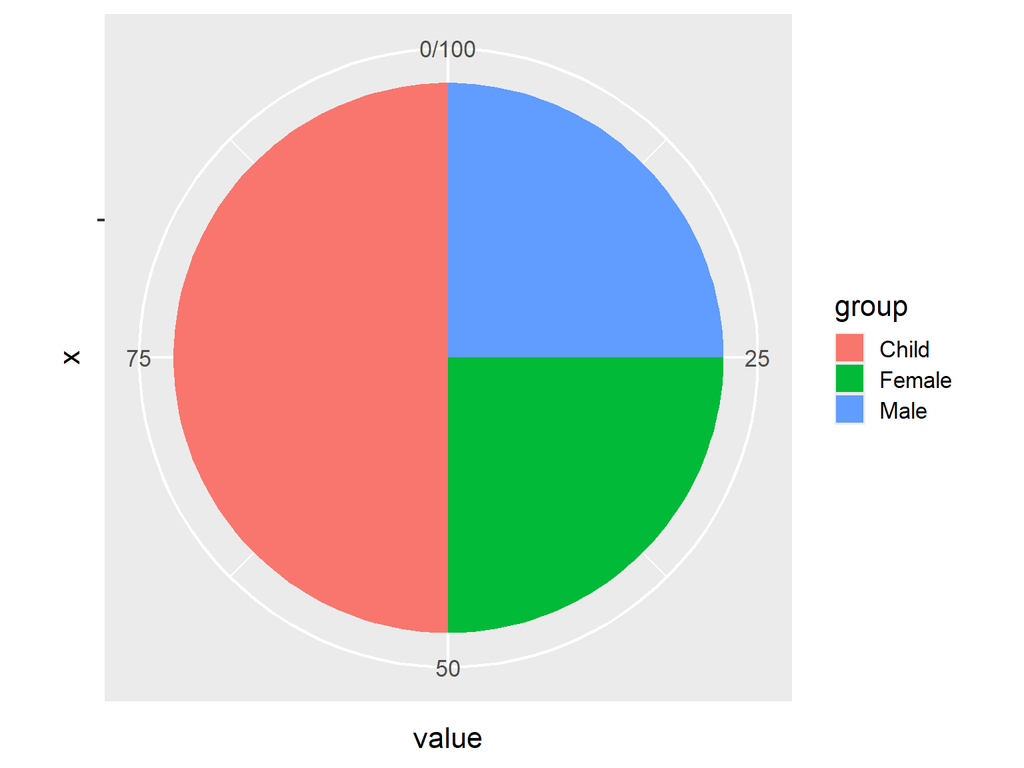

```r
pie <- bp + coord_polar("y", start=0)

pie
```

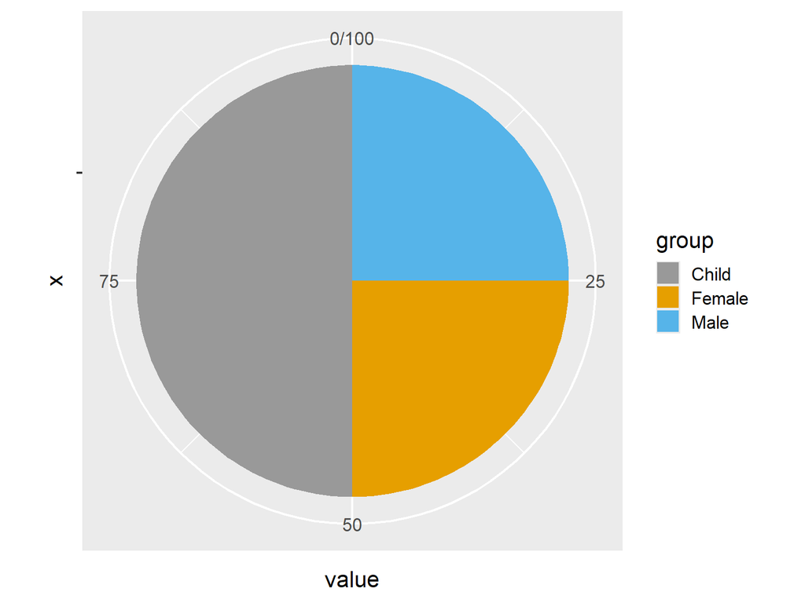

```r
pie + scale_fill_manual(values=c("#999999", "#E69F00", "#56B4E9"))
```

[Additional Resources](http://www.sthda.com/english/wiki/ggplot2-pie-chart-quick-start-guide-r-software-and-data-visualization)

# Quantitative Variables

- Interval or Ratio Scales
  - Histograms
  - Stem plots
  - Time plots

# Histogram

- A histogram is a graphical representation of the distribution of numerical data.
  - Approximates a probability distribution
  - First described in Pearson (1895).

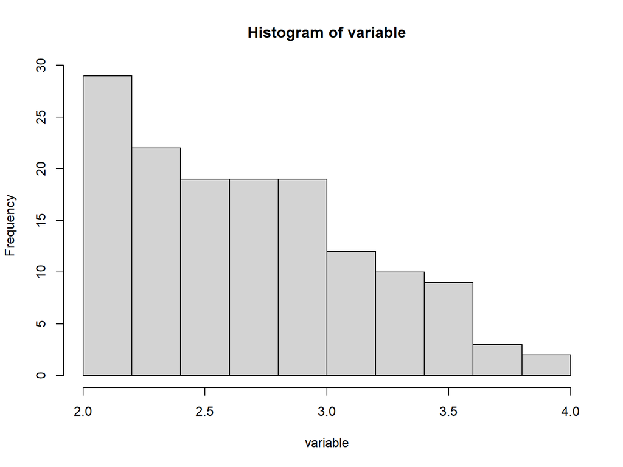

```r
# Histogram
library(MASS)
variable<-cats$Bwt
hist(variable)
```

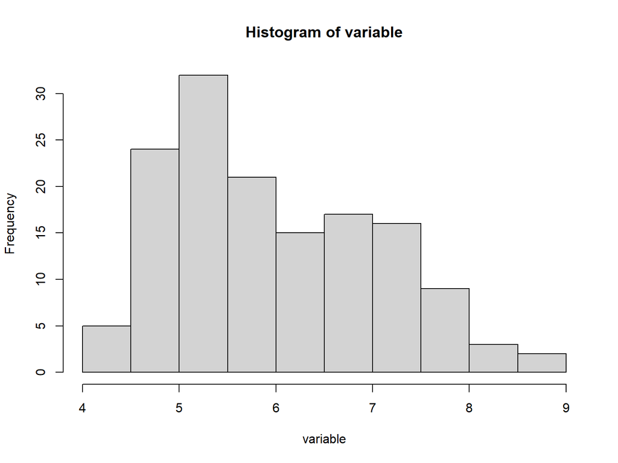

```r
variable<-variable*2.2   #Convert to Imperial
hist(variable)
```

# Stemplot

- Sometimes called a stem and leaf diagram

```r
# Stem and Leaf plot
stem(faithful$eruptions,scale=1)
```

```
##
##   The decimal point is 1 digit(s) to the left of the |
##
##   16 | 070355555588
##   18 | 000022233333335577777777888822335777888
##   20 | 00002223378800035778
##   22 | 0002335578023578
##   24 | 00228
##   26 | 23
##   28 | 080
##   30 | 7
##   32 | 2337
##   34 | 250077
##   36 | 0000823577
##   38 | 2333335582225577
##   40 | 0000003357788888002233555577778
##   42 | 03335555778800233333555577778
##   44 | 02222335557780000000023333357778888
##   46 | 0000233357700000023578
##   48 | 00000022335800333
##   50 | 0370
```

# Time Plots

- Edward Tufte has said that Minard’s plot:

  > “may well be the best statistical graphic ever drawn”
- It packs a ton of information into one dense figure.

# Time Plots

- The plot contains six variables, each mapped to a different aesthetic:

| Information | Aesthetic |
| --- | --- |
| Size of Napoleon’s Grande Armée | Width of path |
| Longitude of the army’s position | x-axis |
| Latitude of the army’s position | y-axis |
| Direction of the army’s movement | Color of path |
| Date of points along retreat path | Text below plot |
| Temperature during the army’s retreat | Line below plot |

# Recreation in R

- This plot has been recreated in R by:
  - [Andrew Heiss](https://www.andrewheiss.com/blog/2017/08/10/exploring-minards-1812-plot-with-ggplot2/)
  - [Michael Friendly](http://www.datavis.ca/gallery/re-minard.php)
  - Wickham (2010) [link](https://www.tandfonline.com/doi/suppl/10.1198/jcgs.2009.07098?scroll=top)

```r
library(tidyverse)
library(lubridate)
library(ggplot2)
library(ggmap)
library(ggrepel)
library(gridExtra)
library(psych)
#Download Directly
download=FALSE # set to true to download
if(download){
 cities <- read.table("https://raw.githubusercontent.com/andrewheiss/fancy-minard/master/input/minard/cities.txt",
                      header = TRUE, stringsAsFactors = FALSE)

 troops <- read.table("https://raw.githubusercontent.com/andrewheiss/fancy-minard/master/input/minard/troops.txt",
                      header = TRUE, stringsAsFactors = FALSE)
 temps <- read.table("https://raw.githubusercontent.com/andrewheiss/fancy-minard/master/input/minard/temps.txt",
                     header = TRUE, stringsAsFactors = FALSE)
}else{


cities <- read.table("../dat/cities.txt",
                     header = TRUE, stringsAsFactors = FALSE)
troops <- read.table("../dat/troops.txt",
                     header = TRUE, stringsAsFactors = FALSE)
temps <- read.table("../dat/temps.txt",
                    header = TRUE, stringsAsFactors = FALSE)
}

describe(cities)
```

```
##       vars  n  mean   sd median trimmed  mad  min  max range  skew kurtosis   se
## long     1 20 30.79 4.08  30.30   30.77 4.74 24.0 37.6  13.6  0.17    -1.31 0.91
## lat      2 20 54.87 0.55  54.95   54.89 0.74 53.9 55.8   1.9 -0.20    -1.18 0.12
## city*    3 20 10.50 5.92  10.50   10.50 7.41  1.0 20.0  19.0  0.00    -1.38 1.32
```

```r
describe(troops)
```

```
##            vars  n     mean        sd  median  trimmed      mad    min      max    range  skew kurtosis       se
## long          1 51    28.97      4.39    28.3    28.56     5.49   24.0     37.7     13.7  0.64    -0.88     0.61
## lat           2 51    54.93      0.51    54.9    54.91     0.74   54.1     55.8      1.7  0.13    -1.29     0.07
## survivors     3 51 91217.65 101718.61 40000.0 72880.49 50408.40 4000.0 340000.0 336000.0  1.31     0.48 14243.45
## direction*    4 51     1.51      0.50     2.0     1.51     0.00    1.0      2.0      1.0 -0.04    -2.04     0.07
## group         5 51     1.43      0.70     1.0     1.29     0.00    1.0      3.0      2.0  1.27     0.15     0.10
```

```r
describe(temps)
```

```
##        vars n   mean    sd median trimmed   mad   min  max range skew kurtosis   se
## long      1 9  30.63  4.30   29.2   30.63  4.15  25.3 37.6  12.3 0.34    -1.56 1.43
## temp      2 9 -15.67 11.10  -20.0  -15.67 13.34 -30.0  0.0  30.0 0.26    -1.66 3.70
## month*    3 9   1.89  0.78    2.0    1.89  1.48   1.0  3.0   2.0 0.15    -1.54 0.26
## day       4 9  14.56  9.46   14.0   14.56 11.86   1.0 28.0  27.0 0.06    -1.72 3.15
## date*     5 9   5.00  2.74    5.0    5.00  2.97   1.0  9.0   8.0 0.00    -1.60 0.91
```

```r
temps$date <- as.Date(strptime(temps$date,"%d%b%Y"))
temps.nice <- temps %>%
  mutate(nice.label = paste0(temp, "°, ", month, ". ", day))
```

[figure not shown]

```r
march.1812.plot.simple <- ggplot() +
  geom_path(data = troops, aes(x = long, y = lat, group = group,
                               color = direction, size = survivors),
            lineend = "round") +
  geom_point(data = cities, aes(x = long, y = lat),
             color = "#DC5B44") +
  geom_text_repel(data = cities, aes(x = long, y = lat, label = city),
                  color = "#DC5B44") +
  scale_size(range = c(0.5, 10)) +
  scale_colour_manual(values = c("#DFC17E", "#252523")) +
  guides(color = FALSE, size = FALSE) +
  theme_nothing()

march.1812.plot.simple
```

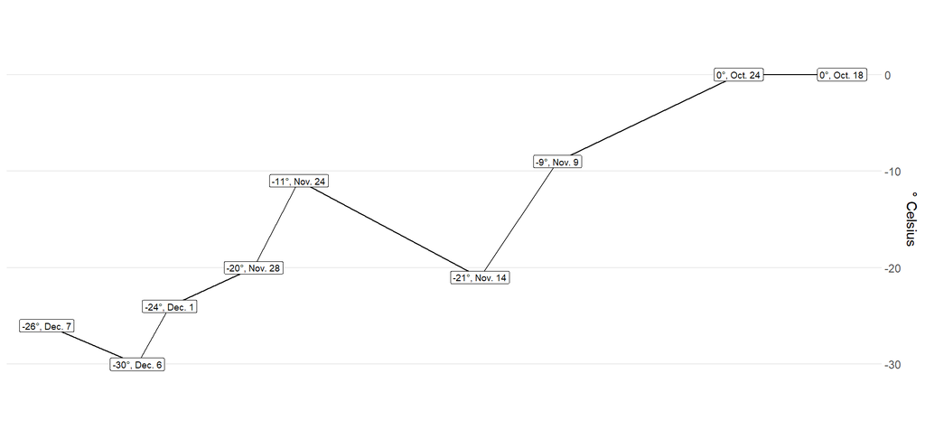

```r
# Change the x-axis limits to match the simple map
temps.1812.plot <- ggplot(data = temps.nice, aes(x = long, y = temp)) +
  geom_line() +
  geom_label(aes(label = nice.label),
             size = 2.5) +
  labs(x = NULL, y = "° Celsius") +
  scale_x_continuous(limits = ggplot_build(march.1812.plot.simple)$layout$panel_ranges[[1]]$x.range) +
  scale_y_continuous(position = "right") +
  coord_cartesian(ylim = c(-35, 5)) +  # Add some space above/below
  theme_bw() +
  theme(panel.grid.major.x = element_blank(),
        panel.grid.minor.x = element_blank(),
        panel.grid.minor.y = element_blank(),
        axis.text.x = element_blank(), axis.ticks = element_blank(),
        panel.border = element_blank())

temps.1812.plot
```

```r
# Combine the two plots
both.1812.plot.simple <- gtable_rbind(ggplotGrob(march.1812.plot.simple),
                               ggplotGrob(temps.1812.plot))

both.1812.plot.simple
```

[figure not shown]

```r
# Adjust panels
panels <- both.1812.plot.simple$layout$t[grep("panel", both.1812.plot.simple$layout$name)]

# Because this plot doesn't use coord_equal,
# since it's not a map, we can use whatever relative numbers we want, like a 3:1 ratio
both.1812.plot.simple$heights[panels] <- unit(c(3, 1), "null")

grid::grid.newpage()
grid::grid.draw(both.1812.plot.simple)
```